# Rfit: Rank-based Estimation for Linear Models

# Writing score functions for *Rfit*

As discussed earlier, we must choose a score function for rank-based fitting. For most datasets the default option of Wilcoxon scores works quite well, however, occasionally choosing a different score function can lead to a more efficient analysis. In this section we first discuss score functions in general and then illustrate how the user may create his own score function. We have placed the score functions in an object of class `"scores"`. A `"scores"` object consists of two objects of type function and an optional numeric object. The functions are the score function `phi` and it’s derivative `Dphi`. The derivative is necessary in estimating $\tau_\varphi$. Below is what the class for Wilcoxon scores looks like.

```r
> wscores
```

```r
An object of class "scores"
Slot "phi":
function(u) sqrt(12)*(u-0.5)

Slot "Dphi":
function(u) rep(sqrt(12),length(u))

Slot "param":
NULL
```

Other score functions included in *Rfit* are listed in Table 1. A plot of the bent score functions is provided in Figure 7. Other score functions can be plotted by getting the scores using the method `getScores`. For example the commands `u<-seq(0.01,0.99,by=0.01)` `plot(u,getScores(nscores,u))` graphs the normal scores.

Table 1: Table of available score functions. Unless otherwise noted, distribution is assumed to be symmetric.

| Score | Keyword | Recommended usage |
| --- | --- | --- |
| Wilcoxon | `wscores` | moderate tailed |
| Normal | `nscores` | light-moderate tailed |
| Bent1 | `bentscores1` | highly right skewed |
| Bent2 | `bentscores2` | light tailed |
| Bent3 | `bentscores3` | highly left skewed |
| Bent4 | `bentscores4` | moderately heavy |
|  |  | tailed |

```r
> bent.phi <- function(u, ...)
+     ifelse(u < 0.5, 8/3 * u - 1, 1/3)
> bent.Dphi <- function(u, ...)
+     ifelse(u < 0.5, 8/3, 0)
> bentscores <- new("scores", phi = bent.phi,
+     Dphi = bent.Dphi)
```

They are displayed graphically in the top left quadrant of Figure 7.

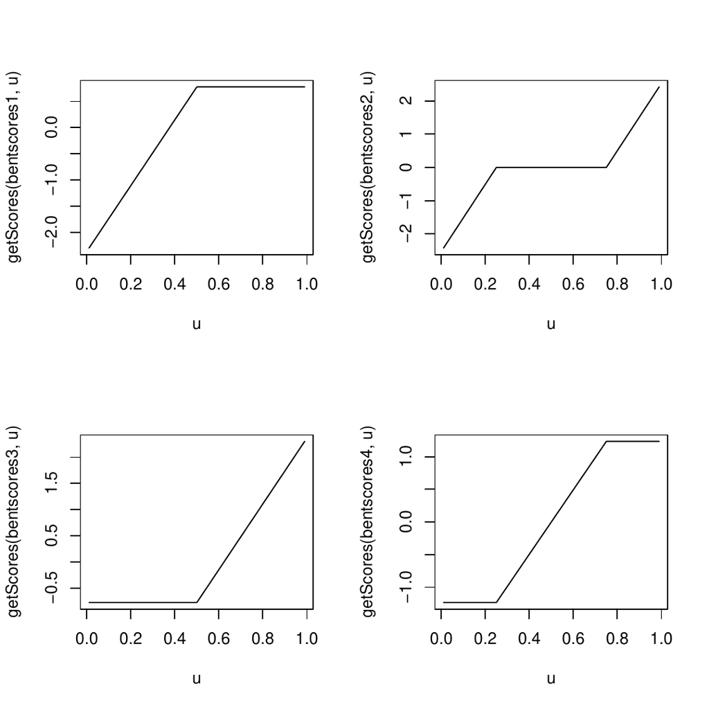

Figure 7: Plots of four bent score functions.

Below we implement the newly defined score functions using the free fatty acid data previously analysed using Wilcoxon scores. One could also use the scores provided by *Rfit* with option `scores=bentscores1` to obtain the same result.

```r
> summary(rfit(ffa ~ age + weight + skin,
+     scores = bentscores, data = ffa))
```

```r
Call:
rfit.default(formula = ffa ~ age + weight + skin,
    scores = bentscores, data = ffa)

Coefficients:
          Estimate  Std. Error t.value   p.value
        1.35957548  0.18882744  7.2001 1.797e-08 ***
age    -0.00048157  0.00178449 -0.2699 0.7888044
weight -0.01539487  0.00260504 -5.9097 9.176e-07 ***
skin    0.35619596  0.09090132  3.9185 0.0003822 ***
---
Signif. codes:
     0 ‘***’ 0.001 ‘**’ 0.01 ‘*’ 0.05 ‘.’ 0.1 ‘ ’ 1

Multiple R-squared (Robust): 0.4757599
Reduction in Dispersion Test:
     11.19278 p-value: 2e-05
```

The results are similar to those presented in Hettmansperger and McKean (2011).

# Summary and future work

This paper illustrates the usage of a new R package, *Rfit*, for rank-based estimation and inference. Rank-based methods are robust to outliers and offer the data analyst an alternative to least squares. *Rfit* includes algorithms for general scores and a library of score functions is included. Functions for regression as well as one-way and multi-way anova are included. We illustrated the use of *Rfit* on several real data sets.

We are in the process of extending *Rfit* to include other robust rank-based procedures which are discussed in Chapters 3 and 5 of Hettmansperger and McKean (2011). These include autoregressive timeseries models, cluster correlated data (mixed models), and nonlinear models. We are also developing weighted versions of rank-based estimation that can be used in mixed effects modeling as discussed in Kloke, J. McKean, and M. Rashid (2009) as well as the computation of high breakdown rank-based estimation discussed in Chang et al. (1999).

*Applied Linear Statistical Models*. 1987. Englewood Cliffs, NJ: Prentice Hall.

Box and D. Cox, G. 1964. *An analysis of transformations*. Journal of the Royal Statistical Society Series B(Methodological) pages.

Chang, William H., Joseph W. McKean, Joshua D. Naranjo, and Simon J. Sheather. 1999. “"High-Breakdown Rank Regression".” *Journal of the American Statistical Association* 94 (445): 205–19.

Crimin, Kim S., A. Abebe, and Joseph W. McKean. 2008. “Robust General Linear Models and Graphics via a User Interface.” *Journal of Modern Applied Statistics* 7: 318–30.

Hettmansperger, T. P., and J. W. McKean. 2011. *Robust Nonparametric Statistical Methods, 2nd Ed.* New York: Chapman Hall.

Hocking, R. R. 1985. *The Analysis of Linear Models*. Brooks/Cole Monterey CA.

Hollander and D. A. Wolfe, M. 1999. *Nonparametric Statistical Methods, Second Edition*. John Wiley & Sons New York New York.

Jaeckel, Louis A. 1972. “"Estimating Regression Coefficients by Minimizing the Dispersion of the Residuals".” *The Annals of Mathematical Statistics* 43: 1449–58.

Jurečková, Jana. 1971. “"Nonparametric Estimate of Regression Coefficients".” *The Annals of Mathematical Statistics* 42: 1328–38.

Kapenga, John, Joseph W. McKean, and Thomas J. Vidmar. 1995. “"RGLM: Users Manual".” 90. Western Michigan University, Department of Mathematics; Statistics.

Kloke, J. McKean, and M. Rashid, J. 2009. *Rank-based estimation and associated inferences for linear models with cluster correlated errors*. Journal of the American Statistical Association 104(485):

Koenker, R. 2011. *quantreg: Quantile Regression,* . R package version 4.69. http://CRAN.R-project.org/package=quantreg.

Koul, H. L., G. Sievers, and J. W. McKean. 1987. “"An Estimator of the Scale Parameter for the Rank Analysis of Linear Models Under General Score Functions".” *Scandinavian Journal of Statistics* 14: 131–41.

McKean and S. Sheather, J. 2009. *Diagnostic procedures*. Wiley Interdisciplinary Reviews: Computational Statistics,1 (2):

McKean and T. Hettmansperger, J. 1978. *A robust analysis of the general linear model based on one step R-estimates*. Biometrika 65 (3): 571.

McKean, J. 2004. *Robust analysis of linear models*. Statistical Science 19 (4):

McKean, J. Terpstra, and J. Kloke, J. 2009. *Computational rank-based statistics*. Wiley Interdisciplinary Reviews: Computational Statistics,1 (2):

Rousseuw, P. J., and A. M. Leroy. 1987. *Robust Regression and Outlier Detection*. New York: Wiley.

Terpstra, J., and J. W. McKean. 2005. “"Rank-Based Analyses of Linear Models Using R".” *Journal of Statistical Software* 14: http://www.jstatsoft.org/.

Venables and B. D. Ripley, W. N. 2002. *Modern Applied Statistics with S*. Springer New York fourth edition. http://www.stats.ox.ac.uk/pub/MASS4.